# A3: SPL Library Checkouts

### Summary Information

The average difference between the checkout date and the publication year is 4.4688087. The highest difference between the checkout year and the publication year was 1999. I calculated the earliest publication year, because I thought this was weird, and it turns out that it was the year 20. The highest number of checkouts was 2950. The average publication year was 2014.9072442 or 2015.

### The Dataset

- **Who collected/published the data?** The data was collected by The Seattle Public Library.
- **What are the parameters of the data (dates, number of checkouts, kinds of books, etc.)?** There are 12 parameters all about chekcout data, such as checkout month, checkout year, publisher of book, book title, subject, etc.. I used checkout year, publication year, subjects, and checkout number.
- **How was the data collected or generated?** They reported the monthly count of SPL checkouts since April of 2005.
- **Why was the data collected?**  
  I couldn’t find the information for that after scouring the internet, but it was under a website that said Seattle Open Access website. I’m assuming that they collected the data so the public could access it easily, because libraries are public access and funded by the government.
- **What, if any, ethical questions do you need to consider when working with this data?**  
  No, I don’t think so. No one’s identity or library accounts were shown when the data was shared. Also those books are checked out so if someone sees a book is missing then they know it’s checked out from the library. All the data exists, so it’s mostly nice that they gave it to people.
- **What are possible limitations or problems with this data?**  
  The publication year was very hard to sort. There was a mix of symbols beside the year, some had two publication years listed. That was a problem, so I just removed those from the dataset, which could’ve skewed my data. The subjects column was disorganized, and I think that fiction vs. nonfiction should have been a seperate column, and genre should be a separate column. I guess I can’t really think of anything else off the top of my head.

### First Trends Over Time Chart

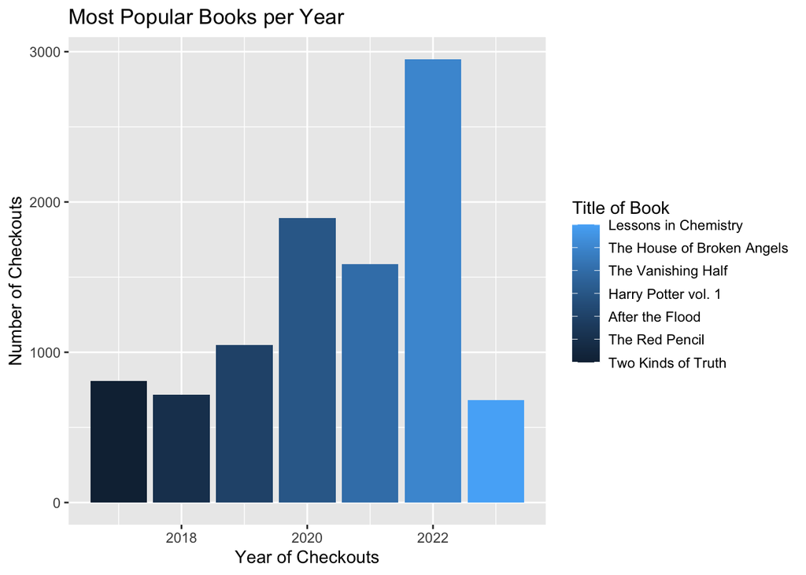

The highest Number of Checkouts for one book was in 2022. The lowest was in 2023.

### Second Trends Over Time Chart

Chart 2: INSIGHT —> I wanted to analyse if popularity of a book depended on age. It doesn’t seem like there’s a trend. All the data seems to go up and down somewhat sporadically. The peak was in 2018, and the lowest was 1933.

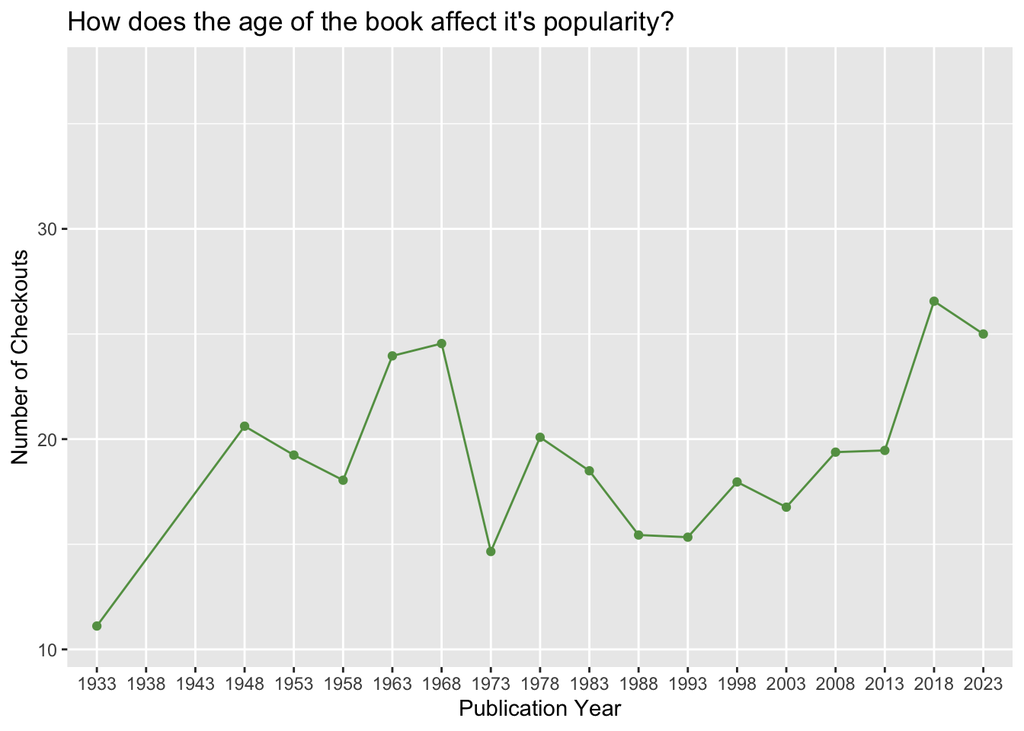

The highest was 2018, the lowest was 1933.

### Your Choice

Chart 3:

INSIGHT —> I wanted to see the frequency of books in each publication year in the data. I will note that any book that hasn’t been checked out wouldn’t be noted in the data, but it seems like there’s an exponential increase in the number of books published every year that has been checked out recently, although there’s a significant drop in 2023. Considering that it’s still the beginning of 2023, this makes sense.

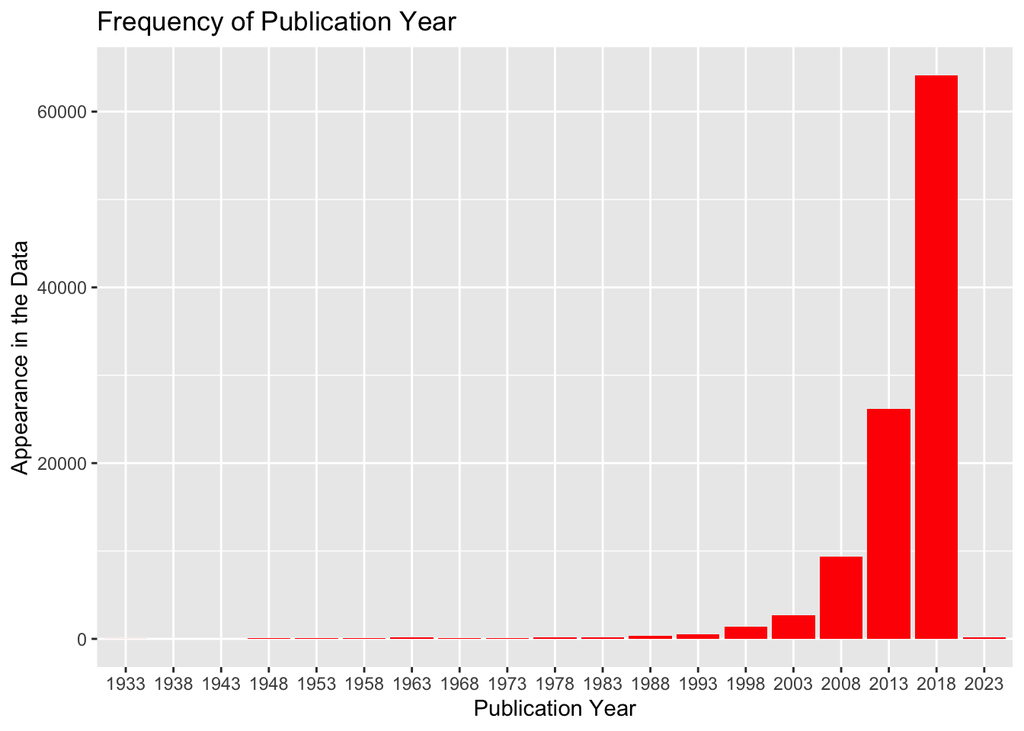